# Prática 7: Testes Qui-Quadrado

Guilherme Rodrigues

21 de fevereiro de 2026

```r
options(encoding = "UTF-8")
#limpar a memória
rm(list = ls())
```

**1)** Um estudo avaliou a preferência alimentar de espécies de peixes ornamentais de água doce. Os diferentes tipos de rações foram ofertados para cada peixe e analisou-se aquela que o peixe mais se alimentou. A partir das informações experimentais obtidas, verifique, por meio de um teste estatístico, se a preferência por algum tipo de ração depende da espécie do peixe, com nível de significância de 0,05.

**Resposta:** Para uma melhor observação dos dados, vamos criar uma tabela de contingência e plotar os dados em um gráfico.

```r
library(readxl)
library(ggplot2)
dados <- read_excel("dados.xlsx", sheet = "Atividade")
head(dados)
```

| Especie | Racao |
| --- | --- |
| Tetras | Liofilizado |
| Tetras | Flocos |
| Tetras | Flocos |
| Tetras | Flocos |
| Tetras | Flocos |
| Tetras | Granulada |

```r
dim(dados)
```

```
## [1] 180   2
```

```r
tabela <- table(dados$Especie, dados$Racao)
tabela
```

```
##
##               Flocos Granulada Liofilizado
##   Neon            17        19          24
##   Paulistinha     24        31           5
##   Tetras          23         6          31
```

```r
round(prop.table(tabela, margin = 1) * 100, 1)
```

```
##
##               Flocos Granulada Liofilizado
##   Neon          28.3      31.7        40.0
##   Paulistinha   40.0      51.7         8.3
##   Tetras        38.3      10.0        51.7
```

```r
#data frame
(tabela2 <- as.data.frame(tabela))
```

| Var1 | Var2 | Freq |
| --- | --- | --- |
| Neon | Flocos | 17 |
| Paulistinha | Flocos | 24 |
| Tetras | Flocos | 23 |
| Neon | Granulada | 19 |
| Paulistinha | Granulada | 31 |
| Tetras | Granulada | 6 |
| Neon | Liofilizado | 24 |
| Paulistinha | Liofilizado | 5 |
| Tetras | Liofilizado | 31 |

```r
colnames(tabela2) <- c("Especie", "Racao", "Freq")

head(tabela2)
```

|  | Especie | Racao | Freq |
| --- | --- | --- | --- |
| 1 | Neon | Flocos | 17 |
| 2 | Paulistinha | Flocos | 24 |
| 3 | Tetras | Flocos | 23 |
| 4 | Neon | Granulada | 19 |
| 5 | Paulistinha | Granulada | 31 |
| 6 | Tetras | Granulada | 6 |

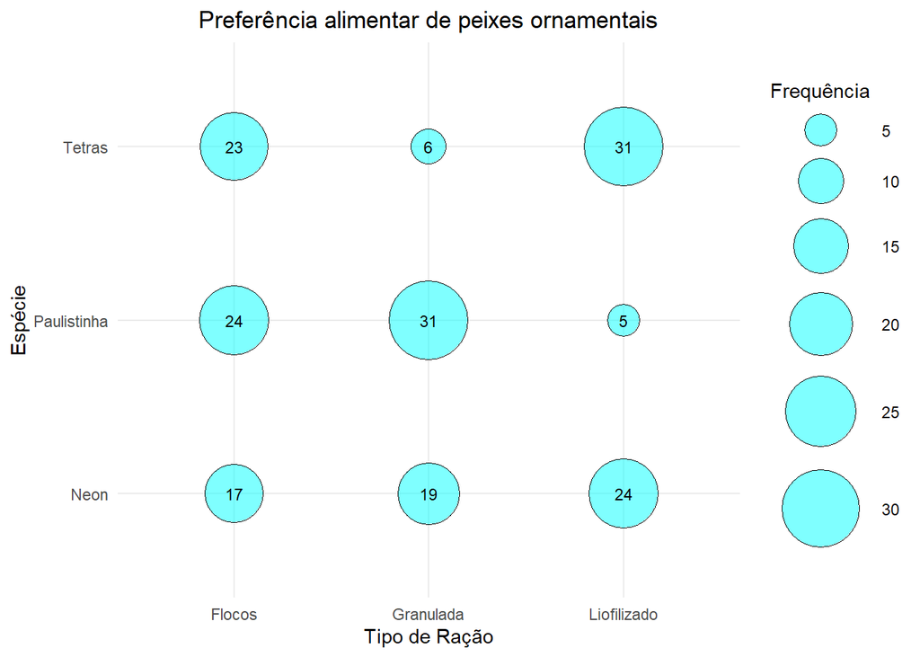

```r
ggplot(tabela2, aes(x = Racao, y = Especie)) +
  geom_point(aes(size = Freq), shape = 21, fill = rgb(0, 1, 1, 0.5)) +
  scale_size_area(max_size = 20) +
  labs(x = "Tipo de Ração", y = "Espécie",
       title = "Preferência alimentar de peixes ornamentais") +
  guides(size = guide_legend(title = "Frequência")) +
  geom_text(aes(label = Freq),
            color = "black",
            size = 3,
            vjust = 0.5, hjust = 0.5) +
  theme_minimal() +
  theme(plot.title = element_text(hjust = 0.5))
```

As hipóteses a serem consideradas são:

$$\left\{ \begin{array}{ll}
H_0:\text{ A preferência alimentar não depende da espécie do peixe
(independência)}\\
H_1:\text{ A preferência alimentar depende da espécie do peixe
(dependência)}
\end{array}\right.$$

Vamos utilizar o teste Qui-Quadrado para comparar os valores observados com os esperados sob independência.

```r
library(pwr)
teste <- chisq.test(tabela)
teste
```

```
##
##  Pearson's Chi-squared test
##
## data:  tabela
## X-squared = 36.194, df = 4, p-value = 2.64e-07
```

```r
teste$observed
```

```
##
##               Flocos Granulada Liofilizado
##   Neon            17        19          24
##   Paulistinha     24        31           5
##   Tetras          23         6          31
```

```r
teste$expected
```

```
##
##                 Flocos Granulada Liofilizado
##   Neon        21.33333  18.66667          20
##   Paulistinha 21.33333  18.66667          20
##   Tetras      21.33333  18.66667          20
```

```r
teste$stdres #resíduos padronizados
```

```
##
##                   Flocos  Granulada Liofilizado
##   Neon        -1.4313493  0.1138456   1.3416408
##   Paulistinha  0.8808303  4.2122886  -5.0311529
##   Tetras       0.5505190 -4.3261343   3.6895122
```

```r
df <- (nrow(tabela)-1)*(ncol(tabela)-1)
chi2 <- as.numeric(teste$statistic)
n    <- sum(tabela)
ES    <- sqrt(chi2 / (n * df)) #gl=4 e n=180

pwr.chisq.test(w = ES, df = df,
               sig.level = 0.05, power = 0.80)
```

```
##
##      Chi squared power calculation
##
##               w = 0.2242077
##               N = 237.4279
##              df = 4
##       sig.level = 0.05
##           power = 0.8
##
## NOTE: N is the number of observations
```

Resultado do teste e interpretação:

- **Teste:** qui-quadrado de independência
- **Estatística:** $\chi^2 = 36.194$
- **Graus de liberdade:** $gl = (r-1)(c-1) = (3-1)(3-1) = 4$
- **p-valor:** $2.64 \times 10^{-7}$

**Decisão:** Como $p < 0.05$, rejeitamos $H_0$. Há evidência estatisticamente significativa de **associação** entre a espécie do peixe e o tipo de ração preferida.

**Tamanho de efeito:** $ES \approx 0.22$.

**Poder do teste:** Para detectar um efeito dessa magnitude com $80\%$ de poder e $\alpha = 0.05$, seriam necessários aproximadamente **237 indivíduos**. O estudo contou com **180**, portanto o experimento não estava bem dimensionado para um poder de 80%.